# Consulting bibliography

Steve Simon

This bibliography was created on 2019-06-06 and last updated on 2019-06-06.

[figure not shown]

Suzanne Bates. Running a Meeting: 10 Rookie Mistakes and How to Avoid Them. Available in [html format](https://www.soa.org/library/newsletters/the-independent-consultant/2008/may/ind-2008-iss19-bates).

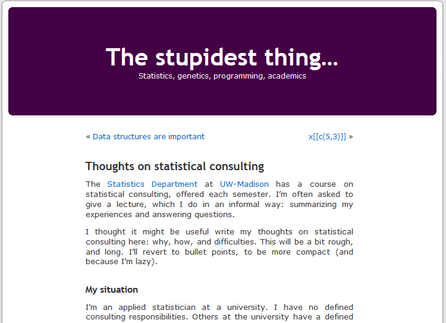

Kenneth Broman. Thoughts on statistical consulting. Available in [html format](https://kbroman.wordpress.com/2013/04/02/thoughts-on-statistical-consulting/).

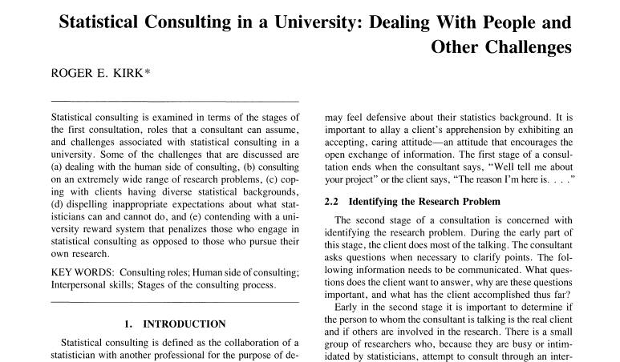

Roger E. Kirk. Statistical Consulting in a University: Dealing with People and Other Challenges. Available in [pdf format](https://www.jstor.org/stable/pdf/2685235.pdf).

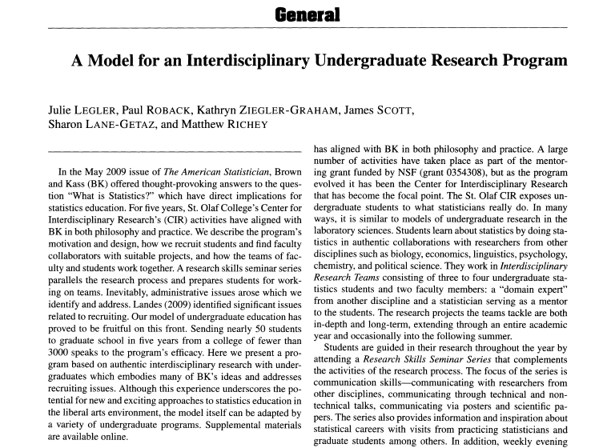

Julie Legler and Paul Roback and Kathryn Ziegler-Graham and James Scott and Sharon Lane-Getaz and Matthew Richey. A Model for an Interdisciplinary Undergraduate Research Program. Available in [pdf format](https://www.jstor.org/stable/pdf/25652349.pdf).

[figure not shown]

Matloff N.. Statistics Losing Ground to Computer Science. Available in [html format](https://magazine.amstat.org/blog/2014/11/01/statistics-losing-ground-to-computer-science/).

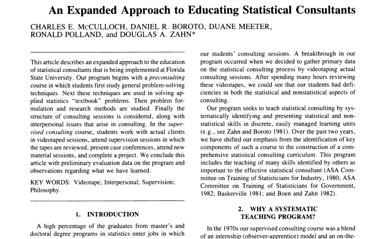

Charles E. McCulloch and Daniel R. Boroto and Duane Meeter and Ronald Polland and Douglas A. Zahn. An Expanded Approach to Educating Statistical Consultants. Available in [pdf format](https://www.jstor.org/stable/pdf/2683923.pdf).

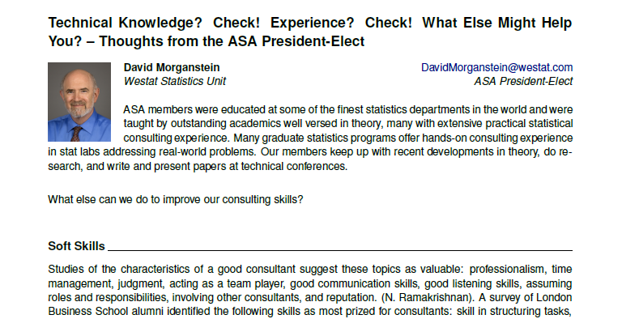

David Morganstein. Technical Knowledge? Check! Experience? Check! What Else Might Help. Available in [pdf format](https://higherlogicdownload.s3.amazonaws.com/AMSTAT/f6e8f6fd-6343-44e2-aa52-8b4e405c5457/UploadedFiles/StatisticalConsultant_v30no3.pdf).

[figure not shown]

Ziaoyue Maggie Niu. My Life as a Statistical Consultant: JSM 2016 Invited Panel Discussion. Available in [html format](https://magazine.amstat.org/blog/2016/10/01/my-life-as-a-statistical-consultant-jsm-2016-invited-panel-discussion/).

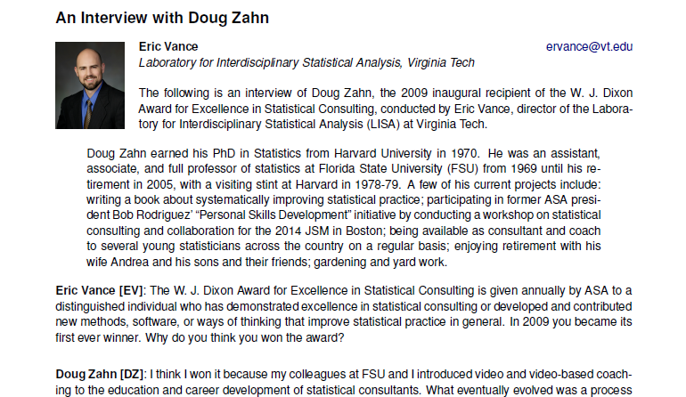

Eric Vance. An Interview with Doug Zahn. Available in [pdf format](http://bit.ly/2b3UGt3).

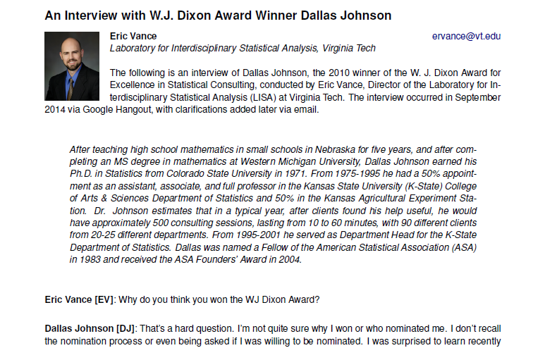

Eric Vance. An Interview with W. J. Dixon Award Winner Dallas Johnson. Available in [pdf format](https://higherlogicdownload.s3.amazonaws.com/AMSTAT/f6e8f6fd-6343-44e2-aa52-8b4e405c5457/UploadedFiles/StatisticalConsultant_v30no3.pdf).

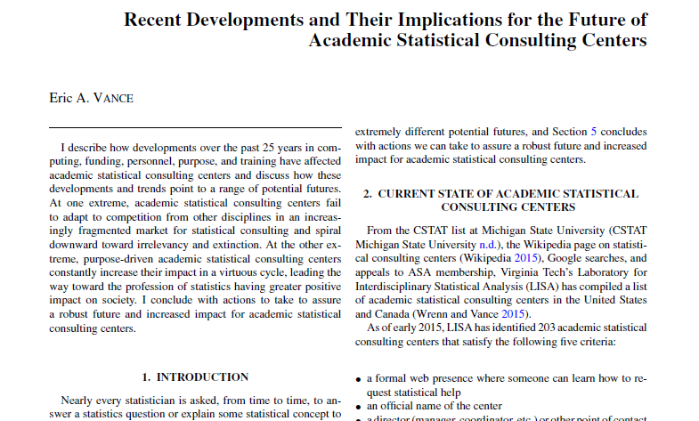

Eric A. Vance. Recent Developments and Their Implications for the Future of Academic Statistical Consulting Centers. Available in [pdf format](https://www.tandfonline.com/doi/abs/10.1080/00031305.2015.1033990).

.